# Practicum 2: Modelling TB in possum populations

Author

Elena Colman & Fiona Harris

# Introduction

Common brushtail possums represent a key reservoir of bovine tuberculosis (TB) in New Zealand. Transmission occurs due to living in close proximity in dens, fighting, mating, and vertical transmission. Possum culling programs and the creation of wildlife management areas have attempted to reduce the impact of TB on the nation’s dairy industry, with varying success.

This paper presents a mathematical model investigating the epidemic and disease dynamics of bovine TB in one den with 50 possums (30 adults and 20 juveniles) into which one infected individual is introduced. While the compartmental model (see below) includes heterogeneity between adults and juveniles **a number of assumptions are made** based on the information provided:

1. Mortality is assumed to be the same for adults and juveniles;
2. The contact transmission rate is the same for all contacts;
3. Vertical transmission to juvenile possums is not limited to females;
4. Transmission does not occur during the latent period and there is no asymptomatic transmission;
5. The den is a closed population, with no possums entering or leaving the den other than the first infected individual;
6. The birth rate differs between susceptible and exposed juveniles as only infected adults can birth exposed juveniles.

## Mathematical model

### Model diagram

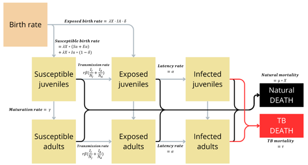

Base model diagram

### Differential equations

$$\begin{align}
\text{Total births} &= \lambda X (S_{A} + E_{A} + I_{A}) \\
\text{Susceptible birth rate} &= \lambda X (S_{A} + E_{A}) + \lambda X I_{A}(1 - \delta) \\
\text{Exposed birth rate} &= \lambda X I_{A} \delta \\
\frac{dS_J}{dt} &= \lambda X (S_{A} + E_{A}) + \lambda X I_{A}(1 - \delta) - (\mu Y + \gamma) S_J - r \beta \left( \frac{I_J}{N_J} + \frac{I_A}{N_A} \right) S_J \\
\frac{dE_J}{dt} &= \lambda X I_{A} \delta + r \beta \left( \frac{I_J}{N_J} + \frac{I_A}{N_A} \right) S_J - (\mu Y + \gamma) E_J - \alpha E_J \\
\frac{dI_J}{dt} &= \alpha E_J - (\mu Y + \gamma + \tau) I_J \\
\frac{dS_A}{dt} &= \gamma S_J - \mu Y S_A - r \beta \left( \frac{I_J}{N_J} + \frac{I_A}{N_A} \right) S_A \\
\frac{dE_A}{dt} &= r \beta \left( \frac{I_J}{N_J} + \frac{I_A}{N_A} \right) S_A + \gamma E_J - (\mu Y + \alpha) E_A \\
\frac{dI_A}{dt} &= \gamma I_J + \alpha E_A - (\mu Y + \tau) I_A
\end{align}$$

Model’s parameters {#tableparameters}

| Symbol | Parameter Name | Explanation | Value | Unit |
| --- | --- | --- | --- | --- |
| λ | lambda | Per capita annual birth rate | 5 | per year |
| κ | kappa | Carrying capacity | 50 | possums per den |
| ρ | rho | Dimensionless parameter for density effects | 0.5 | (Dimensionless) |
| μ | mu | Natural mortality rate (population-modified) | 1/5 | per year |
| τ | tau | TB-induced mortality rate | 1 | per year |
| γ | gamma | Maturation rate (juveniles to adults) | 1 | per year |
| α | alpha | Latency rate (exposed to infectious) | 5 | per year |
| rβ | r beta | Contact transmission rate | 2.1 | per year |
| δ | delta | Vertical transmission rate | 0.1 | per birth |

Model’s modifiers {#tablemodifiers}

| Symbol | Modifier Name | Explanation | Formula |
| --- | --- | --- | --- |
| Y | Mortality modifier | Increases mortality with crowding (logistic function) | \( Y = \frac{1}{1 + \exp(-\rho(N_J + N_{Ad} - \kappa))} \) |
| X | Birth rate modifier | Reduces birth rate based on total population | \( X = 1 - Y \) |

# Baseline infection model

## Infection dynamics

The start population is a total of 50 possums: 20 juveniles and 30 adults. The model starts when 1 infectious adult is introduced to the den.

First 6 Rows of Model Output

| time | SJ | EJ | IJ | SAd | EAd | IAd | natural_deaths | tb_deaths |
| --- | --- | --- | --- | --- | --- | --- | --- | --- |
| 0.0 | 20.00000 | 0.0000000 | 0.0000000 | 30.00000 | 0.0000000 | 1.0000000 | 6.349085 | 1.0000000 |
| 0.1 | 20.95953 | 0.1073589 | 0.0280077 | 31.39984 | 0.1595612 | 0.9332149 | 9.189049 | 0.9612226 |
| 0.2 | 20.30594 | 0.1612992 | 0.0845101 | 32.69441 | 0.2678201 | 0.9373412 | 9.828791 | 1.0218513 |
| 0.3 | 19.33586 | 0.1947515 | 0.1486054 | 33.83559 | 0.3581216 | 0.9921379 | 10.087212 | 1.1407432 |
| 0.4 | 18.31404 | 0.2215881 | 0.2132630 | 34.80657 | 0.4474403 | 1.0885750 | 10.217120 | 1.3018379 |
| 0.5 | 17.32678 | 0.2476225 | 0.2769374 | 35.60271 | 0.5447042 | 1.2239325 | 10.288960 | 1.5008699 |

Last 6 Rows of Model Output

|  | time | SJ | EJ | IJ | SAd | EAd | IAd | natural_deaths | tb_deaths |
| --- | --- | --- | --- | --- | --- | --- | --- | --- | --- |
| 71 | 7.0 | 9.813914 | 4.456148 | 10.37519 | 3.734510 | 2.675349 | 20.79720 | 7.428302 | 31.17239 |
| 72 | 7.1 | 9.813373 | 4.456586 | 10.37926 | 3.732900 | 2.674657 | 20.79491 | 7.427563 | 31.17417 |
| 73 | 7.2 | 9.812907 | 4.456957 | 10.38274 | 3.731534 | 2.674069 | 20.79295 | 7.426928 | 31.17569 |
| 74 | 7.3 | 9.812515 | 4.457273 | 10.38571 | 3.730372 | 2.673571 | 20.79127 | 7.426392 | 31.17698 |
| 75 | 7.4 | 9.812179 | 4.457541 | 10.38825 | 3.729384 | 2.673148 | 20.78983 | 7.425934 | 31.17808 |
| 76 | 7.5 | 9.811892 | 4.457768 | 10.39042 | 3.728544 | 2.672789 | 20.78859 | 7.425542 | 31.17901 |

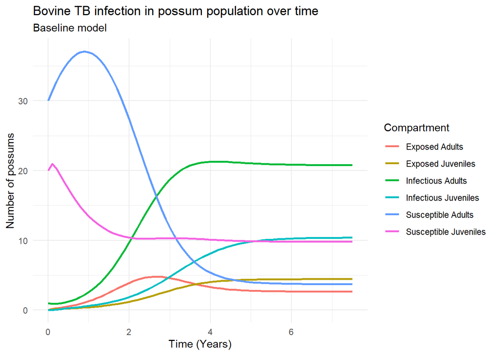

As a result, the influx of newborns exceeds the outflows from the compartment in the first few time steps, leading to a brief initial increase in susceptible juveniles that quickly decreases due to maturation. This results in rapid growth in the susceptible adult population, which peaks after the first year.

The number of exposed juveniles stabilizes at around 5 after 5 years, while the number of exposed adults reaches a maximum of 5 after 2.5 years and decreases to 3 after 4.5 years.

The number of infected juveniles continues to increase and surpasses the number of susceptible juveniles at 5 years, before stabilizing at a population of 11. The number of infected adults grows exponentially in the first two years before stabilizing at around 21 adults.

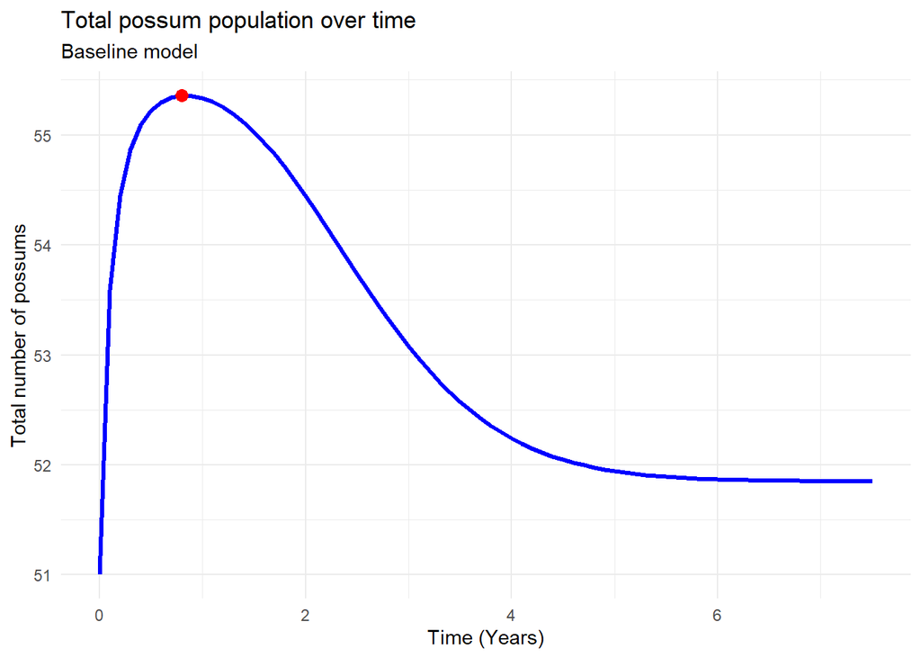

The maximum population in the baseline model was 55 possums reached at 1 years.

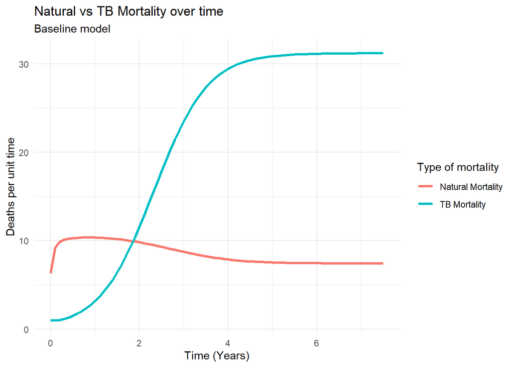